# Modeling Data Mining techniques for Loan Approvals

Group 4**- Rithin Gujja, Srushti Padade, Amruta Deshpande, Chujun Huang

# **Project Goal**

The goal of the project is to design an appropriate asset-management strategy to optimize the economic capital utilization and minimizing the risk to financial investors.

# **Objective**

In this project, we will be running the underwriting department of a bank and will decide who would be approved and who would be rejected. Unlike traditional finance-based approaches to this problem, where one distinguishes between good or bad counterparties in a binary way, we seek to anticipate and incorporate both the default and the severity of the losses that result. In doing so, we are building a bridge between traditional banking, where we are looking at reducing the consumption of economic capital, to an asset-management perspective, where we optimize on the risk to the financial investor.

# **Libraries**

There are various inbuilt libraries in R which has helped us with the Predictive Modeling. Below the libraries are loaded in the enviroment and the algorith they store are directly utilized as needed to perform various Classification and Regression models.

```r
library(VIM)
library(glmnet)
library(glmnetUtils)
library(caret)
library(dplyr)
library(pROC)
library(ggplot2)
library(rpart)
library(randomForest)
library(gmodels)
library(broom)
```

# **Data Loading**

We have a dataset storing an information of a certain bank customers which contains a list of variables and the target variable that is “loss”.

```r
Bank_raw <- read.csv("train_v3.csv")
```

Checking the dimensionality of the dataset.

# **Data Pre-processing**

## Data Cleaning

```r
dim(Bank_raw)
```

```
## [1] 80000   763
```

```r
anyNA(Bank_raw)
```

```
## [1] TRUE
```

The input data consists of information on *80,000* customers in relation to *763* dependent variables to help the bank define their eligibility for financial lending. Here we can see that the dataset have some missing values.

## Imputation

```r
Bank_raw_NA <- Bank_raw
for(i in 1:ncol(Bank_raw)){
  Bank_raw_NA[is.na(Bank_raw_NA[,i]), i] <- median(Bank_raw_NA[,i], na.rm = TRUE)
}
```

```r
anyNA(Bank_raw_NA)
```

```
## [1] FALSE
```

## Normalization

- The data needs to be formated in a normalized manner so the data changes the values of numeric columns in the dataset to a common scale, without distorting differences in the ranges of values.
- The normalized data is used only to compute the dimensionality reduction technique LASSO. Other modeling techniques we are using works the same for unnormalized data.
- We are using the Z-scored Normalzation technique to scale the dataset.

```r
Bank_Scale <- preProcess(Bank_raw_NA,method = c("center","scale"))
Norm_Bank <- predict(Bank_Scale,Bank_raw_NA)
```

# Building a very first Liner model with complete dataset

```r
linearMod <- lm(loss~., data = Norm_Bank)
```

```r
glance(linearMod)
```

| r.squared | adj.r.squared | sigma | statistic | p.value | df | logLik | AIC | BIC | deviance | df.residual |
| --- | --- | --- | --- | --- | --- | --- | --- | --- | --- | --- |
| 0.01766097 | 0.009626466 | 0.9951751 | 2.19814 | 1.701119e-59 | 650 | -112801.8 | 226905.7 | 232953.3 | 78586.14 | 79350 |

Multiple R-squared: 0.01766, Adjusted R-squared: 0.00966. Thus we see the data does not perform well with themodeling and Pre processing of the data is necessary.

## Dimensionality reduction

- The provided dataset have variables with zero variablility. The Lasso regularization help us determine the columns from the dataset that have good impact on the target variable and thus helps in dimensionality reduction.
- We perform linear dimensional reduction using lasso with minimizing sum of squares of error on the dataset.

```r
Lasso_Model<- cv.glmnet(loss~., data = Norm_Bank, alpha = 1, nlambda = 100)
```

```
## Call:
## cv.glmnet.formula(formula = loss ~ ., data = Norm_Bank, alpha = 1,
##     nlambda = 100)
##
## Model fitting options:
##     Sparse model matrix: FALSE
##     Use model.frame: FALSE
##     Number of crossvalidation folds: 10
##     Alpha: 1
##     Deviance-minimizing lambda: 0.002484132  (+1 SE): 0.04048515
```

Lambda which gives minimum mean cross validated error is **Lamba.min**

```
## [1] 0.002484132
```

Ploting the outcome of lasso model

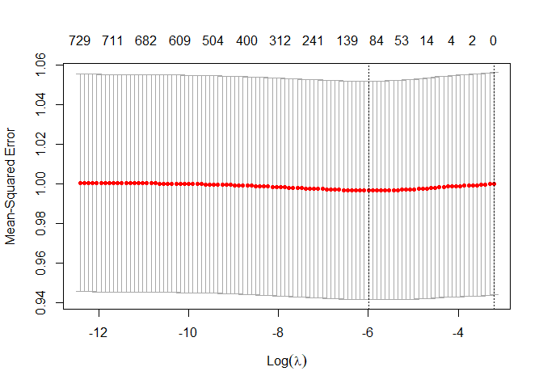

Ploting the dimensionality with respect to lambda min value.

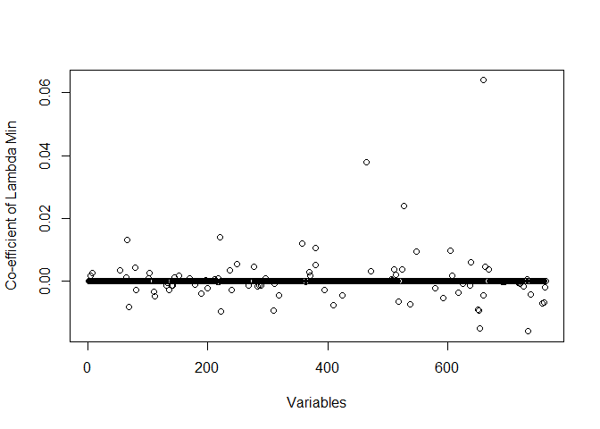

## Variable Selection

Here we are selecting only those variables that were determined from previous Lasso Model for our further modeling.

```r
Train <- select(Bank_raw_NA,f3,f5,f55,f67,f70,f80,f82,f102,f103,f111,f112,f132,f136,f145,f153,f180,f190,f198,f200,f218,f221,f222,f238,f241,f251,f270,f281,f286,f290,f293,f294,f295,f296,f314,f315,f323,f361,f373,f374,f383,f384,f398,f413,f428,f471,f479,f514,f518,f522,f526,f533,f536,f546,f556,f588,f604,f617,f620,f631,f650,f652,f655,f663,f665,f666,f673,f674,f676,f682,f704,f705,f709,f734,f740,f747,f752,f771,f775,f776,loss)
```

## Factorizing target variable

- From the dataset we have our target variable “loss”. “loss” defines the percentage of the loan at which the customer was defaulted. If “loss” is zero you can imagine that the customer has fully paid back the capital and interest. If the “loss” is greater than zero, it means that the customer has defaulted. “loss” is expressed in percentage so if loss is 10, then it means that the customer has paid pack 90% of the capital but zero interests.
- A new variable called loss binary (0 or 1) is created to be used in the classification model. Those customers with defaulted loans are represented by binary digit 1 and without any defaulted loan are represented by 0. This new variable is then added to the training data set with reduced number of variables.

```r
lossbin<-rep(0,80000)

for(i in 1:nrow(Train)){
  if(Train[i,80] > 0){
    lossbin[i] <- 1
  }
}

Train$lossbin <- lossbin
Train$lossbin <- as.factor(Train$lossbin)
```

## Balancing biased date

The dataset we have is biased data with ratio of defaulted customers to non defaulted customers as **1:10**. This unequal type of data the model will surely generate a baise.

Hence to eliminate model biasing we are randomly gathering equal amount of Defaulted to Non defaulted amount of Customers Data.

```r
NoLoss <- Train %>% filter(lossbin==0)
Loss <- Train %>% filter(lossbin==1)

Random_NoLoss <- sample(1:nrow(NoLoss),nrow(Loss),replace = FALSE)
NoLoss_Train_Data <- NoLoss[Random_NoLoss,]
Train_Unbaised <- rbind(NoLoss_Train_Data, Loss)
TrainClass_Unbaised <- Train_Unbaised[,-80]
```

## Data Partitioning

### *Classification*

- To check the performance of the Model we are partitioning the unbaised data.
- Considering 80% data for TRAINING the model and 20% as VALIDATION data.

```r
set.seed(2019)

index_C <- createDataPartition(TrainClass_Unbaised$lossbin, p = 0.8, list = FALSE)
Train_Class <- TrainClass_Unbaised[index_C,] # Train data
Valid_Class <- TrainClass_Unbaised[-index_C,] # Valid data
```

### *Regression*

- To build a regression model we are considering only the data of the Customers who are Defaulted. Using this data we can see the percentage by which the customer is defaulted. i.e. from variable “loss”

```r
## Considering variables where loss is only greater than 0
Loss_Data <- filter(Train_Unbaised,lossbin == 1)
Loss_Data <- Loss_Data[,-81]
```

```r
set.seed(2019)

index_R <- createDataPartition(Loss_Data$loss, p = 0.8, list = FALSE)
Train_Reg <- Loss_Data[index_R,]
Valid_Reg <- Loss_Data[-index_R,]
```

# **Modeling**

## *Classification*

- Our foremost objective is to find which Customers who are likely to Default and which Customer would not. To extract this information we are building a Classification Model which will classify customers as *DEFAULTED(1)* and *NONDEFAULTED(0)*.
- To achieve this objective we are considering few Classification models and looking for the one with better performance on our data.

### Generalized Classification Model

```r
Class_Model <- train(lossbin~.,data = Train_Class, method ='glmnet',
                     tuneGrid = expand.grid(alpha = 0,lambda = c(seq(0.1, 2, by = 0.1), seq(2, 5, 0.5), seq(5, 25, 1))))

Class_Valid <- predict(Class_Model, Valid_Class)
Class_ConfusionMatrix <- confusionMatrix(Class_Valid, Valid_Class$lossbin)
```

```
## glmnet
##
## 11808 samples
##    79 predictor
##     2 classes: '0', '1'
##
## No pre-processing
## Resampling: Bootstrapped (25 reps)
## Summary of sample sizes: 11808, 11808, 11808, 11808, 11808, 11808, ...
## Resampling results across tuning parameters:
##
##   lambda  Accuracy   Kappa
##    0.1    0.6344966  0.2691300
##    0.2    0.6297957  0.2597298
##    0.3    0.6275346  0.2552103
##    0.4    0.6257185  0.2515796
##    0.5    0.6242443  0.2486319
##    0.6    0.6229625  0.2460760
##    0.7    0.6216644  0.2434827
##    0.8    0.6210741  0.2423093
##    0.9    0.6206068  0.2413806
##    1.0    0.6200757  0.2403279
##    1.1    0.6196443  0.2394734
##    1.2    0.6189282  0.2380529
##    1.3    0.6189279  0.2380570
##    1.4    0.6185044  0.2372162
##    1.5    0.6179897  0.2361950
##    1.6    0.6175858  0.2353946
##    1.7    0.6172260  0.2346816
##    1.8    0.6169120  0.2340583
##    1.9    0.6169396  0.2341214
##    2.0    0.6165906  0.2334323
##    2.5    0.6158164  0.2319183
##    3.0    0.6151155  0.2305489
##    3.5    0.6147939  0.2299430
##    4.0    0.6146273  0.2296504
##    4.5    0.6142036  0.2288382
##    5.0    0.6138536  0.2281789
##    6.0    0.6133101  0.2271589
##    7.0    0.6129342  0.2264855
##    8.0    0.6124270  0.2255565
##    9.0    0.6120478  0.2248806
##   10.0    0.6116961  0.2242545
##   11.0    0.6110859  0.2231086
##   12.0    0.6105428  0.2220961
##   13.0    0.6102109  0.2215104
##   14.0    0.6097962  0.2207557
##   15.0    0.6094827  0.2201934
##   16.0    0.6090417  0.2193862
##   17.0    0.6083871  0.2181446
##   18.0    0.6080190  0.2174831
##   19.0    0.6071089  0.2157419
##   20.0    0.6063717  0.2143325
##   21.0    0.6059756  0.2136065
##   22.0    0.6054779  0.2126745
##   23.0    0.6046974  0.2111832
##   24.0    0.6039223  0.2097041
##   25.0    0.6031594  0.2082480
##
## Tuning parameter 'alpha' was held constant at a value of 0
## Accuracy was used to select the optimal model using the largest value.
## The final values used for the model were alpha = 0 and lambda = 0.1.
```

#### Cross Table Validation

```r
CrossTable(Valid_Class$lossbin, Class_Valid, prop.chisq = FALSE)
```

```
##
##
##    Cell Contents
## |-------------------------|
## |                       N |
## |           N / Row Total |
## |           N / Col Total |
## |         N / Table Total |
## |-------------------------|
##
##
## Total Observations in Table:  2950
##
##
##                     | Class_Valid
## Valid_Class$lossbin |         0 |         1 | Row Total |
## --------------------|-----------|-----------|-----------|
##                   0 |       889 |       586 |      1475 |
##                     |     0.603 |     0.397 |     0.500 |
##                     |     0.646 |     0.373 |           |
##                     |     0.301 |     0.199 |           |
## --------------------|-----------|-----------|-----------|
##                   1 |       488 |       987 |      1475 |
##                     |     0.331 |     0.669 |     0.500 |
##                     |     0.354 |     0.627 |           |
##                     |     0.165 |     0.335 |           |
## --------------------|-----------|-----------|-----------|
##        Column Total |      1377 |      1573 |      2950 |
##                     |     0.467 |     0.533 |           |
## --------------------|-----------|-----------|-----------|
##
##
```

#### Confusion Matrix

```
## Confusion Matrix and Statistics
##
##           Reference
## Prediction   0   1
##          0 889 488
##          1 586 987
##
##                Accuracy : 0.6359
##                  95% CI : (0.6183, 0.6533)
##     No Information Rate : 0.5
##     P-Value [Acc > NIR] : < 2.2e-16
##
##                   Kappa : 0.2719
##
##  Mcnemar's Test P-Value : 0.003078
##
##             Sensitivity : 0.6027
##             Specificity : 0.6692
##          Pos Pred Value : 0.6456
##          Neg Pred Value : 0.6275
##              Prevalence : 0.5000
##          Detection Rate : 0.3014
##    Detection Prevalence : 0.4668
##       Balanced Accuracy : 0.6359
##
##        'Positive' Class : 0
##
```

### Ensemble learning model - Random Forest

- Ensemble models in machine learning combine the decisions from multiple models to improve the overall performance.
- Here we used Random Forest which is an ensemble learning method for classification, that operates by constructing a multitude of decision trees at training time and outputting the class that is the mode of the classes (classification)

```r
RF_Model <- train(lossbin~., data = Train_Class, method = 'rf', ntree = 300)

RF_Valid <- predict(RF_Model, Valid_Class)

RF_ConfusionMatrix <- confusionMatrix(RF_Valid, Valid_Class$lossbin)
```

```
## Random Forest
##
## 11808 samples
##    79 predictor
##     2 classes: '0', '1'
##
## No pre-processing
## Resampling: Bootstrapped (25 reps)
## Summary of sample sizes: 11808, 11808, 11808, 11808, 11808, 11808, ...
## Resampling results across tuning parameters:
##
##   mtry  Accuracy   Kappa
##    2    0.6234601  0.2471231
##   40    0.6310361  0.2622606
##   79    0.6296218  0.2594660
##
## Accuracy was used to select the optimal model using the largest value.
## The final value used for the model was mtry = 40.
```

#### Cross Table Validation

```r
CrossTable(Valid_Class$lossbin, RF_Valid, prop.chisq = FALSE)
```

```
##
##
##    Cell Contents
## |-------------------------|
## |                       N |
## |           N / Row Total |
## |           N / Col Total |
## |         N / Table Total |
## |-------------------------|
##
##
## Total Observations in Table:  2950
##
##
##                     | RF_Valid
## Valid_Class$lossbin |         0 |         1 | Row Total |
## --------------------|-----------|-----------|-----------|
##                   0 |       905 |       570 |      1475 |
##                     |     0.614 |     0.386 |     0.500 |
##                     |     0.665 |     0.359 |           |
##                     |     0.307 |     0.193 |           |
## --------------------|-----------|-----------|-----------|
##                   1 |       456 |      1019 |      1475 |
##                     |     0.309 |     0.691 |     0.500 |
##                     |     0.335 |     0.641 |           |
##                     |     0.155 |     0.345 |           |
## --------------------|-----------|-----------|-----------|
##        Column Total |      1361 |      1589 |      2950 |
##                     |     0.461 |     0.539 |           |
## --------------------|-----------|-----------|-----------|
##
##
```

#### Confusion Matrix

```
## Confusion Matrix and Statistics
##
##           Reference
## Prediction    0    1
##          0  905  456
##          1  570 1019
##
##                Accuracy : 0.6522
##                  95% CI : (0.6347, 0.6694)
##     No Information Rate : 0.5
##     P-Value [Acc > NIR] : < 2.2e-16
##
##                   Kappa : 0.3044
##
##  Mcnemar's Test P-Value : 0.000419
##
##             Sensitivity : 0.6136
##             Specificity : 0.6908
##          Pos Pred Value : 0.6650
##          Neg Pred Value : 0.6413
##              Prevalence : 0.5000
##          Detection Rate : 0.3068
##    Detection Prevalence : 0.4614
##       Balanced Accuracy : 0.6522
##
##        'Positive' Class : 0
##
```

### Support Vector Machine

The objective of the support vector machine algorithm is to find a hyperplane in an N-dimensional space(N - the number of features) that distinctly classifies the data points.

```r
SVM_Model<-train(lossbin~., data = Train_Class, method="svmLinear")

SVM_Valid <- predict(SVM_Model, Valid_Class)
SVM_ConfusionMatrix <- confusionMatrix(SVM_Valid, Valid_Class$lossbin)
```

```
## Support Vector Machines with Linear Kernel
##
## 11808 samples
##    79 predictor
##     2 classes: '0', '1'
##
## No pre-processing
## Resampling: Bootstrapped (25 reps)
## Summary of sample sizes: 11808, 11808, 11808, 11808, 11808, 11808, ...
## Resampling results:
##
##   Accuracy   Kappa
##   0.6418855  0.283705
##
## Tuning parameter 'C' was held constant at a value of 1
```

#### Cross Table Validation

```r
CrossTable(Valid_Class$lossbin, SVM_Valid, prop.chisq = FALSE)
```

```
##
##
##    Cell Contents
## |-------------------------|
## |                       N |
## |           N / Row Total |
## |           N / Col Total |
## |         N / Table Total |
## |-------------------------|
##
##
## Total Observations in Table:  2950
##
##
##                     | SVM_Valid
## Valid_Class$lossbin |         0 |         1 | Row Total |
## --------------------|-----------|-----------|-----------|
##                   0 |       874 |       601 |      1475 |
##                     |     0.593 |     0.407 |     0.500 |
##                     |     0.673 |     0.364 |           |
##                     |     0.296 |     0.204 |           |
## --------------------|-----------|-----------|-----------|
##                   1 |       425 |      1050 |      1475 |
##                     |     0.288 |     0.712 |     0.500 |
##                     |     0.327 |     0.636 |           |
##                     |     0.144 |     0.356 |           |
## --------------------|-----------|-----------|-----------|
##        Column Total |      1299 |      1651 |      2950 |
##                     |     0.440 |     0.560 |           |
## --------------------|-----------|-----------|-----------|
##
##
```

#### Confusion Matrix

```
## Confusion Matrix and Statistics
##
##           Reference
## Prediction    0    1
##          0  874  425
##          1  601 1050
##
##                Accuracy : 0.6522
##                  95% CI : (0.6347, 0.6694)
##     No Information Rate : 0.5
##     P-Value [Acc > NIR] : < 2.2e-16
##
##                   Kappa : 0.3044
##
##  Mcnemar's Test P-Value : 4.671e-08
##
##             Sensitivity : 0.5925
##             Specificity : 0.7119
##          Pos Pred Value : 0.6728
##          Neg Pred Value : 0.6360
##              Prevalence : 0.5000
##          Detection Rate : 0.2963
##    Detection Prevalence : 0.4403
##       Balanced Accuracy : 0.6522
##
##        'Positive' Class : 0
##
```

```r
RF_Pred <- predict(RF_Model, Valid_Class, type = "prob")
SVM_Pred <- predict(SVM_Model, Valid_Class, decision.values = TRUE, probability = TRUE)
LM_Pred <- predict(Class_Model, Valid_Class, type = "prob")

RF_RoC <- roc(Valid_Class$lossbin, RF_Pred[,2])
SVM_Roc <- roc(Valid_Class$lossbin, as.numeric(SVM_Pred))
LM_Roc <- roc(Valid_Class$lossbin, LM_Pred[,2])
```

## *Regression*

- The Regression model are built in order to predict the Continuous Target Variable.
- Using classification model we can already predict if a customer will Default or not, but in order to know at what rate the Customer is likely to default in paying back the loan amount we are building Regression Models.
- Here we are building few models to predict the defaulted percentage and then we will select the best performing model to predict our test data.

### Lasso Regression

LASSO (least absolute shrinkage and selection operator) is a regression analysis method that performs both variable selection and regularization in order to enhance the prediction accuracy and interpretability of the statistical model it produces.

```r
RegLasso_Model <- train(loss~., data = Train_Reg, method ='glmnet', trControl = trainControl(method = "cv",number = 10),
                        tuneGrid = expand.grid(alpha = 1, lambda = c(seq(0.001, 0.5, by = 0.01))), metric = "Rsquared")
```

```
## glmnet
##
## 5905 samples
##   79 predictor
##
## No pre-processing
## Resampling: Cross-Validated (10 fold)
## Summary of sample sizes: 5315, 5314, 5314, 5315, 5315, 5315, ...
## Resampling results across tuning parameters:
##
##   lambda  RMSE       Rsquared   MAE
##   0.001    9.944779  0.2783766  5.778626
##   0.011    9.938625  0.2789411  5.758930
##   0.021    9.937058  0.2788815  5.745569
##   0.031    9.937818  0.2785508  5.734230
##   0.041    9.941306  0.2778858  5.725824
##   0.051    9.946004  0.2770745  5.719691
##   0.061    9.949968  0.2763877  5.714343
##   0.071    9.952085  0.2759486  5.708505
##   0.081    9.954841  0.2754443  5.704242
##   0.091    9.956660  0.2751217  5.699394
##   0.101    9.957798  0.2749100  5.694173
##   0.111    9.959471  0.2746351  5.689480
##   0.121    9.961122  0.2743810  5.684734
##   0.131    9.962468  0.2741934  5.679602
##   0.141    9.963681  0.2740327  5.674572
##   0.151    9.965004  0.2738678  5.669889
##   0.161    9.966181  0.2737474  5.665177
##   0.171    9.967576  0.2736091  5.660929
##   0.181    9.969235  0.2734433  5.657005
##   0.191    9.971201  0.2732374  5.653380
##   0.201    9.973313  0.2730195  5.649888
##   0.211    9.975580  0.2727895  5.646524
##   0.221    9.977975  0.2725484  5.643403
##   0.231    9.980383  0.2723113  5.640300
##   0.241    9.982954  0.2720557  5.637421
##   0.251    9.985743  0.2717737  5.634801
##   0.261    9.988735  0.2714673  5.632490
##   0.271    9.991846  0.2711487  5.630362
##   0.281    9.995257  0.2707873  5.628394
```

[output cut: 10 more lines]

```
##   0.391   10.037766  0.2662562  5.616002
##   0.401   10.041295  0.2659231  5.614642
##   0.411   10.044917  0.2655794  5.613479
##   0.421   10.048480  0.2652467  5.612154
##   0.431   10.051925  0.2649364  5.610785
##   0.441   10.055394  0.2646253  5.609536
##   0.451   10.058961  0.2643018  5.608507
##   0.461   10.062541  0.2639818  5.607623
##   0.471   10.066118  0.2636671  5.606804
##   0.481   10.069678  0.2633585  5.606041
##   0.491   10.073337  0.2630366  5.605457
##
## Tuning parameter 'alpha' was held constant at a value of 1
## Rsquared was used to select the optimal model using the largest value.
## The final values used for the model were alpha = 1 and lambda = 0.011.
```

##### Prediction on training set

```r
RegLasso_Train <- predict(RegLasso_Model, Train_Reg)
RSqar_RegLasso_Train <- (cor(Train_Reg$loss,RegLasso_Train)^2)
RMSE_Lasso_Train <- sqrt(mean((Train_Reg$loss - RegLasso_Train)^2))
```

##### Prediction on validation set

```r
RegLasso_Valid <- predict(RegLasso_Model, Valid_Reg)
RSqar_RegLasso_Model <- (cor(Valid_Reg$loss,RegLasso_Valid)^2)
RMSE_Lasso <- sqrt(mean((Valid_Reg$loss - RegLasso_Valid)^2))
```

#### Performance Measure

| Train_R-Square | Valid_R-Square | Train_RMSE | Valid_RMSE |
| --- | --- | --- | --- |
| 0.3012664 | 0.2972472 | 9.783261 | 9.777089 |

### Ensemble Learning Model - Random Forest

We are again using the emsembling model for the regression modeling to check the performance of Random forest model on predicting the Continuous target variable

```r
RegRF_Model<-train(loss~.,data = Train_Reg, method ='rf', ntree = 500, tuneGrid = expand.grid(.mtry = c(seq(15, 40, by = 5))))
```

```
## Random Forest
##
## 5905 samples
##   79 predictor
##
## No pre-processing
## Resampling: Bootstrapped (25 reps)
## Summary of sample sizes: 5905, 5905, 5905, 5905, 5905, 5905, ...
## Resampling results across tuning parameters:
##
##   mtry  RMSE      Rsquared   MAE
##   15    9.765733  0.2867942  5.600706
##   20    9.755891  0.2875365  5.584370
##   25    9.774452  0.2843673  5.585816
##   30    9.786988  0.2824810  5.592640
##   35    9.801793  0.2803999  5.594185
##   40    9.821515  0.2775671  5.600276
##
## RMSE was used to select the optimal model using the smallest value.
## The final value used for the model was mtry = 20.
```

##### Prediction on training set

```r
RegRF_Train <- predict(RegRF_Model, Train_Reg)
RSqar_RegRF_Train <- (cor(Train_Reg$loss,RegRF_Train)^2)
RMSE_RF_Train <- sqrt(mean((Train_Reg$loss - RegRF_Train)^2))
```

##### Prediction on validation set

```r
RegRF_Valid <- predict(RegRF_Model, Valid_Reg)
RSqar_RegRF_Model <- (cor(Valid_Reg$loss, RegRF_Valid)^2)
RMSE_RF <- sqrt(mean((Valid_Reg$loss - RegRF_Valid)^2))
```

#### Performance Measure

| Train_R-Square | Valid_R-Square | Train_RMSE | Valid_RMSE |
| --- | --- | --- | --- |
| 0.9362194 | 0.3316741 | 4.138721 | 9.59937 |

```r
RegXGBoost_Model <- train(loss~., data = Train_Reg, method = "blackboost")
```

```
## Boosted Tree
##
## 5905 samples
##   79 predictor
##
## No pre-processing
## Resampling: Bootstrapped (25 reps)
## Summary of sample sizes: 5905, 5905, 5905, 5905, 5905, 5905, ...
## Resampling results across tuning parameters:
##
##   maxdepth  mstop  RMSE      Rsquared   MAE
##   1          50    10.54265  0.2236332  5.814118
##   1         100    10.32313  0.2449817  5.668618
##   1         150    10.25079  0.2523919  5.659676
##   2          50    10.12912  0.2719991  5.567879
##   2         100    10.04633  0.2809847  5.526750
##   2         150    10.04633  0.2809847  5.526750
##   3          50    10.03495  0.2818664  5.498475
##   3         100    10.02902  0.2826401  5.495403
##   3         150    10.02902  0.2826401  5.495403
##
## RMSE was used to select the optimal model using the smallest value.
## The final values used for the model were mstop = 100 and maxdepth = 3.
```

##### Prediction on training set

```r
RegXGBoost_Train <- predict(RegXGBoost_Model, Train_Reg)
RSqar_RegXGBoost_Train <- (cor(Train_Reg$loss,RegXGBoost_Train)^2)
RMSE_RegXGBoost_Train <- sqrt(mean((Train_Reg$loss - RegXGBoost_Train)^2))
```

##### Prediction on validation set

```r
RegXGBoost_Valid <- predict(RegXGBoost_Model, Valid_Reg)
RSqar_RegXGBoost_Model <- (cor(Valid_Reg$loss, RegXGBoost_Valid)^2)
RMSE_XGBoost <- sqrt(mean((Valid_Reg$loss - RegXGBoost_Valid)^2))
```

#### Performance Measure

| Train_R-Square | Valid_R-Square | Train_RMSE | Valid_RMSE |
| --- | --- | --- | --- |
| 0.4154343 | 0.2959364 | 9.067834 | 9.822344 |

# **Conclusion**

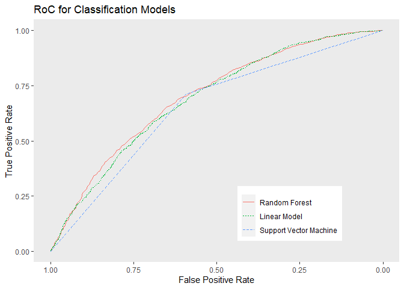

|  | Train_R-Square | Valid_R-Square | Train_RMSE | Valid_RMSE |
| --- | --- | --- | --- | --- |
| Lasso | 0.3012664 | 0.2972472 | 9.783261 | 9.777089 |
| Random_Forest | 0.9362194 | 0.3316741 | 4.138721 | 9.599370 |
| XGBoost | 0.4154343 | 0.2959364 | 9.067834 | 9.822344 |